# CalcBehavior

An attempt to semi-theoretically analyze the efficacy of different nested training methods.

```r
library('ggplot2')
source('utils.R')
source('modelCat.R')
source('cbFns.R')
source('bindValues.R')
commonFns <- ls()
parallelCluster <- parallel::makeCluster(parallel::detectCores())
set.seed(23225)

varValues <- list()
signalValues <- paste('g',1:6,sep='')
varValues[['group']] <- signalValues
# add in noise groups
noiseGroups <- paste('n',1:2,sep='')
for(gName in noiseGroups) {
  gValues <- paste(gName,1:6,sep='.')
  varValues[[gName]] <- gValues
}
allVars <- c('group',noiseGroups)

# complete uniform test design
dTest <- expand.grid(varValues,stringsAsFactors=FALSE)
print(head(dTest))
```

```
##   group   n1   n2
## 1    g1 n1.1 n2.1
## 2    g2 n1.1 n2.1
## 3    g3 n1.1 n2.1
## 4    g4 n1.1 n2.1
## 5    g5 n1.1 n2.1
## 6    g6 n1.1 n2.1
```

```r
print(dim(dTest))
```

```
## [1] 216   3
```

We are going to form estimates of the form P(y=TRUE|group). The model will be est_group is some sort of empirical estimate per-group derived from training and then the overall model is of the form P(y|group)~s(b*est_group) where s is the sigmoid function and b is estimated by logistic regression. For this case (a single variable) this second outer model is not needed. We also could alternately model a logistic regression directly on the group labels.

What we are trying to do is make a simple example showing the problems one can run into when building a nested model which is a method used when the group variable takes on a very large number of values (such as zip codes) (see http://www.win-vector.com/blog/2012/07/modeling-trick-impact-coding-of-categorical-variables-with-many-levels/ ). We are deliberately looking for the over-fit that comes from such a nested model, and what methods decrease this undesirable effect (see: http://winvector.github.io/DiffPriv/DiffPriv.pdf ).

The idea in this exercise is we are going to have the unknown true probablity P(y|group) as 1-x or x depending on the group label (x, being a variable we vary from 0 to 1) for all groups. The inner conditoned estimate (called “est”) can be estimated a few ways including:

- Naive or empirical esimate: est_group = N(y|group)/N(group)
- Jackknifed estimate: est_group = (N(y|group)-selfY)/(N(group)-1)
- Half Jackknifed: est_group = (N(y|group)-selfY/2)/(N(group)-1/2)
- Split: est_group = N(y|group in first half of training data)/N(group in first half of training data)

The second stage (or overall model) is then simulated using logistic regression (R’s glm() command). We estimate P(y|group) as s(b*group_est) (b being the fit coefficient, for the split case we use only the disjoint second half of the data for estimation of b).

The idea is: in many cases the naive or empirical estimate is already over-fitting (or memorizing training data). So we would would like the outter modeling procedure to correct this (or at least not make this worse). However, in the naive case the outter fitting procedure is pretty much forced to pick a coefficient b=1 and does not correct. However, if there is some de-coupling of the empirical estimates the fitter is allowed to see from the actual training data (such as Jackknife, split procedures, or even differential privacy established through the introduction of noise as in slide 18 of http://www.slideshare.net/SessionsEvents/misha-bilenko-principal-researcher-microsoft ) then we get better generalization performance (b is picked less than 1).

It is the relative strength or statistical effiency of each of these techniques we wish to demonstrate. To do this we are going to assume the group labels of our data set are fixed (they being the fixed experimental design) and then assume we see the y-lables with y=TRUE with probablity x (x being a parameter we will vary from 0 through 1). Because for each x there are exactly 2^nrow(d) possible y assignments and we can exactly compute the probability of any y assignment we can sum over every possible observed data set weighted according to the exact probability of each data set occuring. For each possible observed data set we can compute the outcomes and we thus know the exact probabilities of each possible outcome. In fact we can write these probabilities and expectations as polynomials in x, allowing us to leave x as a parameter to be explored later (versus having to substitue in a specific value). In this manner we are going to estimate the following summaries of the fits (as functions of x):

- The expected value of max_group s(b*group_est) over all models. That is: for each composite model (empirical estimate plus outter model) we find which group it things has the largest probabilty and report this probability.
- The expected value of min_group s(b*group_est) the smallest prediction
- The expected value of mean_group s(b*group_est) the expected mid-prediction

In all cases the expectation is taken over all possible realizaitons of the traning vector y with y=TRUE having probability x (x a variable to be filled in later).

The first step is estimating y conditioned on group, the second is a glm() model on top of this estimate. The nested model usually gives trouble as the group variable can hide degrees of freedom and cause over-fitting.

```r
runExperiment <- function(d,experimentName) {
  print("***********************************")
  n <- nrow(d)
  # placeholder for y
  d$y <- NA
  print(d)
  print(n)
  print(experimentName)

  plotObliv <- evalModelingStrategy(d,dTest,signalValues,noiseGroups,
                                  constModel,c(),
                                  'oblivious model',
                                  parallelCluster,commonFns)$plotD
  pruneLevel <- 0.5
  plotPrune <- evalModelingStrategy(d,dTest,signalValues,noiseGroups,
                                  prunedModel,pruneLevel,
                                  paste('significance',pruneLevel,'pruned model'),
                                  parallelCluster,commonFns)$plotD
  plotNaive <-  evalModelingStrategy(d,dTest,signalValues,noiseGroups,
                                  naiveModel,c(),
                                  'naive prediction',
                                  parallelCluster,commonFns)$plotD
  plotJackknife <-  evalModelingStrategy(d,dTest,signalValues,noiseGroups,
                                  jackknifeModel,c(),
                                  'jackknife prediction',
                                  parallelCluster,commonFns)$plotD

  # run multiple noise plans
  sigma <- 4
  lnPlots <- lapply(1:20,
                    function(i) {
                      noisePlan <- mkNoisePlan(d,unique(c('group',noiseGroups)),sigma)
                      plot <- evalModelingStrategy(d,dTest,signalValues,noiseGroups,
                                                   noisedModelFixed,noisePlan,
                                                   paste('Noised (sigma=',
                                                         sigma,') prediction\ntry=',
                                                         i,sep=''),
                                                   parallelCluster,commonFns)$plotD
                      list(noisePlan=noisePlan,
                           plot=plot)
                    }
  )
  plotLNoise <- lnPlots[[1]]$plot

  # run an averaging of noise plans
  nPlans <- lapply(lnPlots,
                   function(r) {
                     r$noisePlan
                   })
  plotAvgNoised <- evalModelingStrategy(d,dTest,signalValues,noiseGroups,
                                  noisedModelFixedV2,nPlans,
                                  paste('Noised averaged prediction (sigma=',sigma,')',
                                        sep=''),
                                  parallelCluster,commonFns)$plotD


  # show performance
  print(ggplot(data=plotNaive,
               mapping=aes(x=x,
                           y=expectedDeviance,
                           color=what)) +
          geom_line(size=2,color="#d95f02") +
          scale_color_brewer(palette='Dark2') +
          ggtitle(paste('Expected test deviance\n',experimentName)))
  print(ggplot(data=rbind(plotNaive,plotJackknife,plotLNoise),
               mapping=aes(x=x,
                           y=expectedDeviance,
                           color=what,fill=what)) +
          geom_line(size=2) +
          scale_color_brewer(palette='Dark2') +
          ggtitle(paste('Expected test deviance\n',experimentName)))
  print(ggplot(data=rbind(plotNaive,plotJackknife,plotLNoise,plotAvgNoised),
               mapping=aes(x=x,
                           y=expectedDeviance,
                           color=what,fill=what)) +
          geom_line(size=2) +
          scale_color_brewer(palette='Dark2') +
          ggtitle(paste('Expected test deviance\n',experimentName)))
  print(ggplot(data=rbind(plotNaive,plotJackknife,plotAvgNoised,plotPrune),
               mapping=aes(x=x,
                           y=expectedDeviance,
                           color=what,fill=what)) +
          geom_line(size=2) +
          scale_color_brewer(palette='Dark2') +
          ggtitle(paste('Expected test deviance\n',experimentName)))
  print(ggplot(data=rbind(plotObliv,plotNaive,plotJackknife,plotAvgNoised,plotPrune),
               mapping=aes(x=x,
                           y=expectedDeviance,
                           color=what,fill=what)) +
          geom_line(size=2) +
          scale_color_brewer(palette='Dark2') +
          ggtitle(paste('Expected test deviance\n',experimentName)))

  # show many different noised models
  lnPlotsP <- lapply(seq_len(length(lnPlots)),
                     function(i) {
                       p <- lnPlots[[i]]$plot
                       p$rep <- i
                       p
                     })
  lPlotFrame <- do.call(rbind,lnPlotsP)
  print(ggplot() +
          geom_line(data=plotLNoise,mapping=aes(x=x,
                                                y=expectedDeviance),
                    color='#7570b3') +
          geom_line(data=plotAvgNoised,mapping=aes(x=x,
                                                   y=expectedDeviance),
                    color='#e7298a') +
          geom_line(data=lPlotFrame,mapping=aes(x=x,
                                                y=expectedDeviance,
                                                group=rep),
                    alpha=0.2) +
          ggtitle(paste('Expected test deviance\nnoised models]\n',experimentName)))
}
```

Random experimental design.

```r
dRand <- dTest[sample.int(nrow(dTest),12,replace=TRUE),]
runExperiment(dRand,'random design (12 rows)')
```

```
## [1] "***********************************"
##     group   n1   n2  y
## 89     g5 n1.3 n2.3 NA
## 63     g3 n1.5 n2.2 NA
## 110    g2 n1.1 n2.4 NA
## 73     g1 n1.1 n2.3 NA
## 173    g5 n1.5 n2.5 NA
## 200    g2 n1.4 n2.6 NA
## 142    g4 n1.6 n2.4 NA
## 22     g4 n1.4 n2.1 NA
## 145    g1 n1.1 n2.5 NA
## 15     g3 n1.3 n2.1 NA
## 148    g4 n1.1 n2.5 NA
## 72     g6 n1.6 n2.2 NA
## [1] 12
## [1] "random design (12 rows)"
```

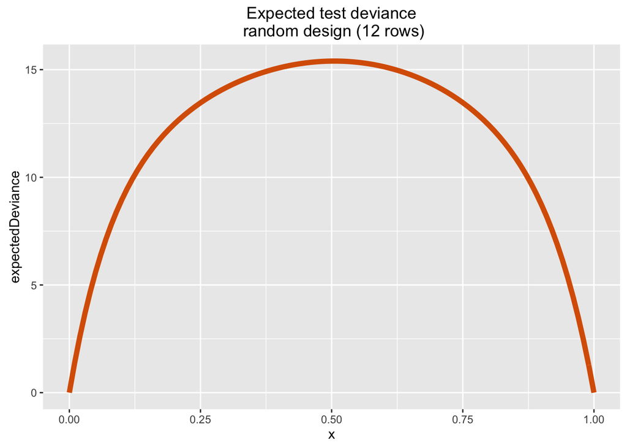

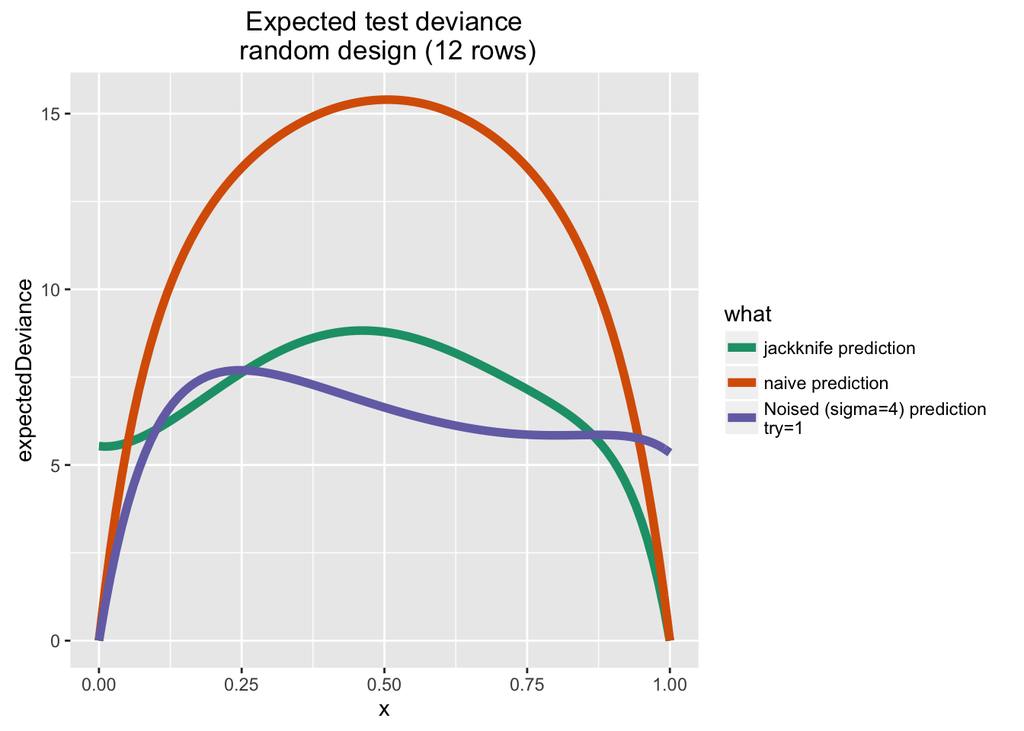

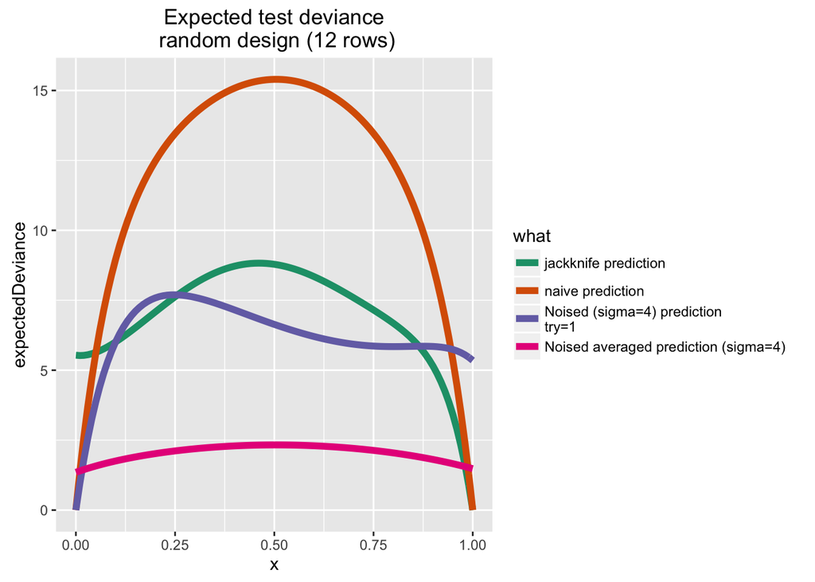

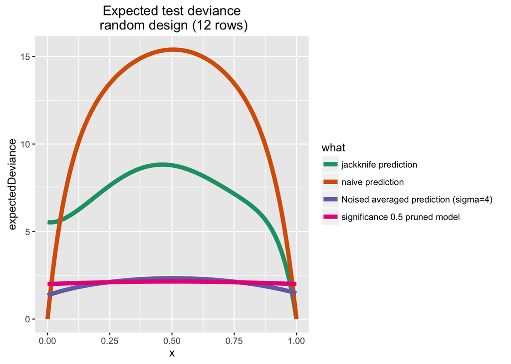

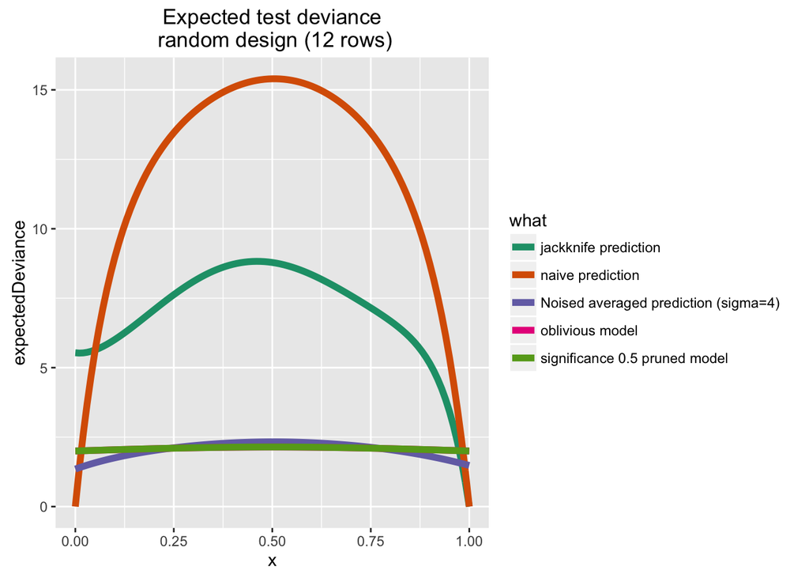

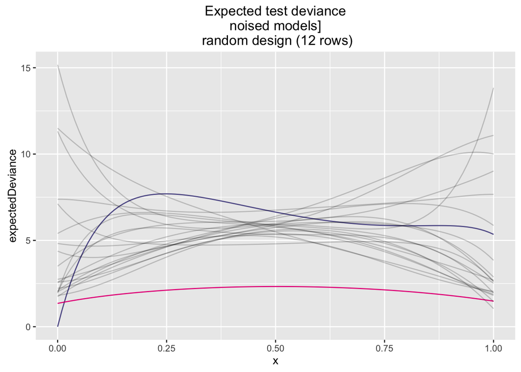

Experiment where each level occurs exactly once.

```r
dOne <- tryFor1design(6,allVars,dTest)
runExperiment(dOne,'1-design (6 rows)')
```

```
## [1] "***********************************"
##     group   n1   n2  y
## 85     g1 n1.3 n2.3 NA
## 117    g3 n1.2 n2.4 NA
## 170    g2 n1.5 n2.5 NA
## 184    g4 n1.1 n2.6 NA
## 23     g5 n1.4 n2.1 NA
## 72     g6 n1.6 n2.2 NA
## [1] 6
## [1] "1-design (6 rows)"
```

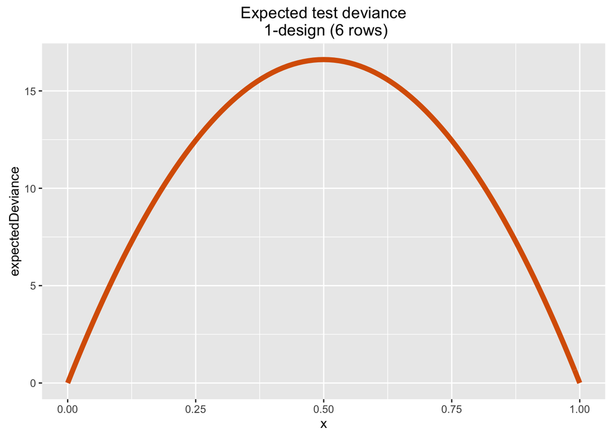

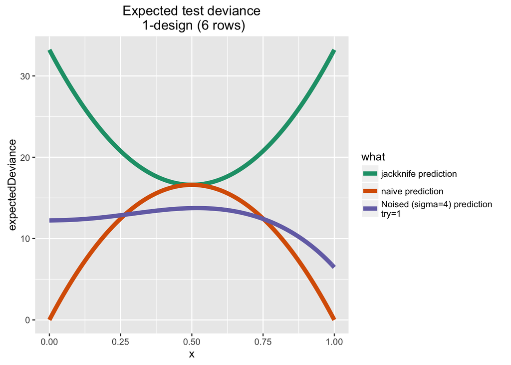